# CVS Twitter Sentiment Analysis

John Akwei, ECMp ERMp Data Scientist

Wednesday, September 30, 2015

[figure not shown]

## Synopsis

This document is a demonstration of a Company in the process of investigating its public image. The Twitter sentiment investigation within this document identifies Social Media content, expressing what the public associated with the name of the Company.

## Table of Contents

1. General Twitter Sentiment
2. CVS Twitter Sentiment
3. Differentiating General Sentiment vs. CVS Twitter Sentiment
4. Possible Problems with the Analytical Process
5. Conclusions

```
## [1] "Using browser based authentication"
```

## 1) General Twitter Sentiment

```r
# General Twitter content
twitter <- readLines("en_US.twitter.txt", encoding="UTF-8")

# Function to clean the general twitter text
textOptimal <- function(corpus){
  cleanText <- removePunctuation(corpus)
  cleanText <- removeNumbers(cleanText)
  cleanText <- str_replace_all(cleanText, "[^[:alnum:]]", " ")
  cleanText <- stripWhitespace(cleanText)
  cleanText <- tolower(cleanText)
  return(cleanText)}

# Sample of 1000 General Tweets
twitterOptimal <- textOptimal(twitter[1:1000])
```

#### Five lines of General Twitter Sentiment:

```r
# Example of a General Tweet
twitterOptimal[1:5]
```

```
## [1] "how are you btw thanks for the rt you gonna be in dc anytime soon love to see you been way way too long"
## [2] "when you meet someone special youll know your heart will beat more rapidly and youll smile for no reason"
## [3] "theyve decided its more fun if i dont"
## [4] "so tired d played lazer tag ran a lot d ughh going to sleep like in minutes "
## [5] "words from a complete stranger made my birthday even better "
```

#### General Twitter Sentiment Wordcloud:

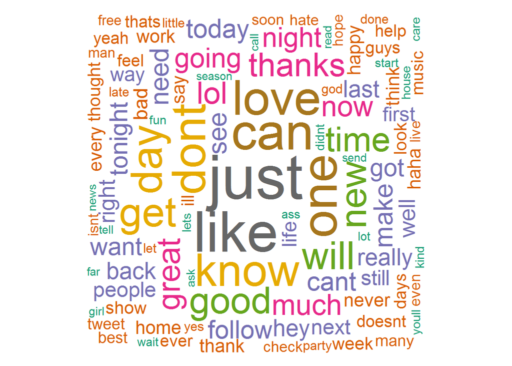

[figure not shown]

```r
# Wordcloud of General Tweets
wordcloud (twitterOptimal, scale=c(5,0.5), max.words=200, random.order=F,
           rot.per=0.35, use.r.layout=F, colors=brewer.pal(8, 'Dark2'))
```

#### Analysis of the General Twitter community:

As can be seen in the above 5 lines of general twitter sentiment, the accompanying wordcloud, and the above summary of word frequencies, random twitter comments tend towards expressing personal interests, and activities. Occasionally, popular Corporations are mentioned, although infrequently.

## 2) CVS Twitter Sentiment

```r
# @CVS_Extra information
library(twitteR)
Qinfo <- getUser("CVS_Extra")
Qinfo$followersCount
```

```
## [1] 281074
```

```r
# Tweets referencing CVS_Extra
Qtext <- searchTwitter('CVS', n=100)
```

#### 5 lines of CVS Twitter Sentiment:

```r
Qsentiment <- do.call("rbind", lapply(Qtext, as.data.frame))
Qsentiment[1:5, 1]
```

```
## [1] "CVS is hiring a #Retail #Store Shift Supervisor, apply now! #NewYork #jobs http://t.co/wMgVDObTDW"
## [2] "Can you recommend anyone for this #job? Pharmacy Technician Trainee \\ Pharmacy Service Associate - http://t.co/m4JbCaTTQb #ESSEX, VT"
## [3] ".@InfoSecSherpa @TimothyDeBlock Next year, I'll head down to the CVS, grab a wine in the box, put the schwag waterbottle to good use..."
## [4] "#BOOKKEEPER needed; independent school in Jhb. Please see our Facebook page for more info. CVs to TheTeacherNetwork@iafrica.com please."
## [5] "#McComb, MS #Retail #Job: Retail Store Shift Supervisor at CVS Health http://t.co/JfwpEAluwX #Jobs #Hiring #CareerArc"
```

#### CVS Sentiment Wordcloud:

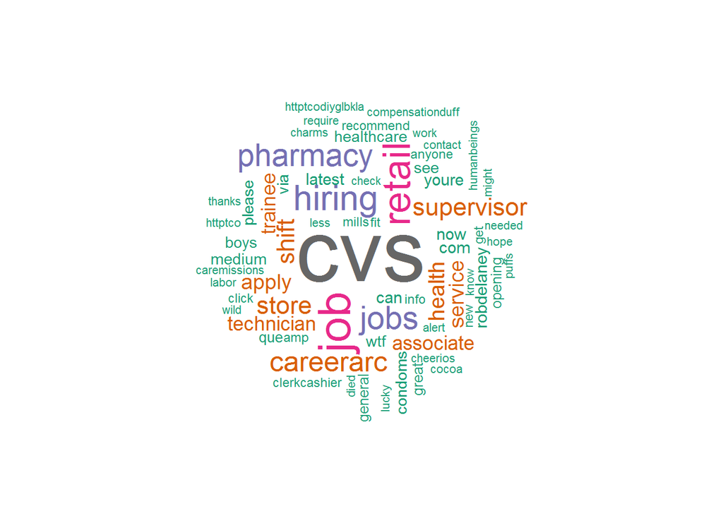

[figure not shown]

```r
CVSOptimal <- textOptimal(Qsentiment[,1])

# WordCloud of tweets referencing CVS
wordcloud (as.character(CVSOptimal), scale=c(5,0.5), max.words=200, random.order=F, rot.per=0.35, use.r.layout=F, colors=brewer.pal(8, 'Dark2'))
```

#### Analysis of Twitter Sentiment towards CVS:

As can be seen in the above 5 lines of CVS twitter sentiment, the accompanying wordcloud, and the above word frequency analysis, twitter comments about CVS tend towards informing Individuals in the Public about Employment opportunities at CVS. Less frequently mentioned are planned visits to CVS, and items that Individuals plan to buy at CVS.

## 3) Differentiating General Sentiment vs. CVS Sentiment

```r
# Tweets posted on the @CVS_Extra timeline
Qtimeline <- userTimeline('@CVS_Extra')
Qcontent <- do.call("rbind", lapply(Qtimeline, as.data.frame))
```

#### 5 lines from @CVS_Extra Timeline:

```r
Qcontent[1:5, 1]
```

```
## [1] "@Dre_Yonce (2/2) Can you please DM us your contact info so we can get in touch with you on your experience? Thank you!"
## [2] "@rbpray Thanks for reaching out. We've let customer service know and someone will be calling you today."
## [3] "@MarylandGirl85 Hope you have a great shopping trip, Fallon!"
## [4] "@natpenn We apologize for this, Natalie! Please DM us your contact info so we can get this resolved for you. Thx!"
## [5] "@Antony511 We'd like to learn more about this and assist, Antony! Please DM us your contact info and we'll get in touch."
```

#### @CVS_Extra Timeline Wordcloud:

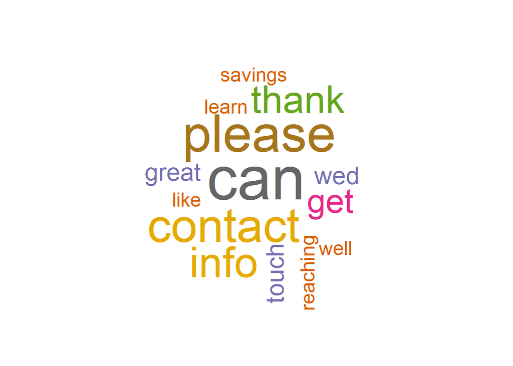

[figure not shown]

```r
# WordCloud of tweets referencing CVS
wordcloud (as.character(Qcontent[,1]), scale=c(5,0.5), max.words=200, random.order=F, rot.per=0.35, use.r.layout=F, colors=brewer.pal(8, 'Dark2'))
```

#### Analysis of internal @CVS_Extra Twitter comments:

As can be seen in the above 5 lines of @CVS internal comments, the accompanying wordcloud, and the above word frequency analysis, @CVS internal comments tend towards resolving Customer inquiries, and verbally rewarding Customers for patronage of CVS.

### Combination of General, CVS Public, CVS Timeline Wordcloud:

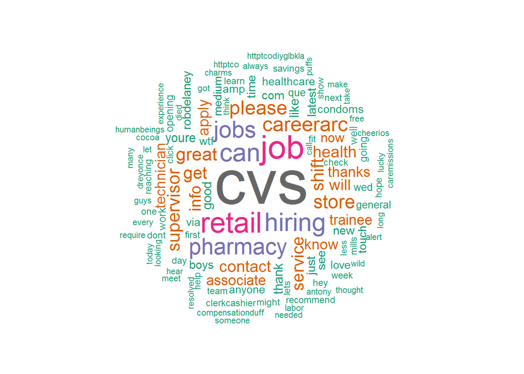

```r
# Combine TheCompanyTimeline with GeneralTwitter and TheCompanyPublicTweets
cloud <- c(Qcontent[1:100, 1], twitterOptimal[1:100], CVSOptimal)
wordcloud (cloud, scale=c(5,0.5), max.words=200, random.order=F, rot.per=0.35, use.r.layout=F, colors=brewer.pal(8, 'Dark2'))
```

#### Analysis of differences in Internal CVS twitter comments, and external twitter comments about CVS:

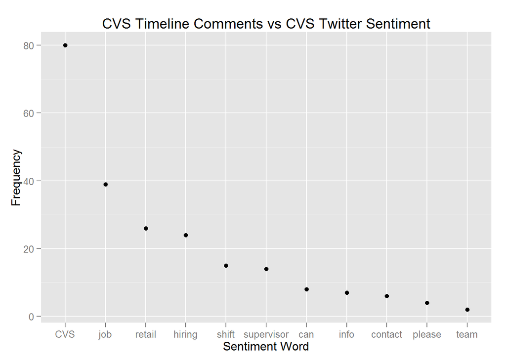

```r
Freq <- as.numeric(c(8, 7, 6, 4, 2, 80, 39, 26, 24, 15, 14))
Terms <- c("can", "info", "contact", "please", "team", "CVS", "job", "retail", "hiring", "shift", "supervisor")
Terms <- data.frame(Terms)
FreqTable <- cbind(Terms, Freq)
FreqTable <- data.frame(FreqTable)
ggplot(FreqTable, aes(x=reorder(FreqTable$Terms, -FreqTable$Freq), y=FreqTable$Freq)) +
geom_point() +
labs (x="Sentiment Word", y="Frequency",
title="CVS Timeline Comments vs CVS Twitter Sentiment")
```

## 4) Possible Problems with the Analytical Process

The creater of this document, (ContextBase), has a high level of assuredness in the reliability of the source data in portraying general Twitter comments, public Twitter comments about CVS, and comments posted to CVS’ timeline.

The general, random twitter comments are from a reliable corpora, ( available from http://www.corpora.heliohost.org. The same twitter corpora is also found at http://d396qusza40orc.cloudfront.net/dsscapstone/dataset/Coursera-SwiftKey.zip).

## 5) Conclusions

As can be seen in the above analysis of CVS twitter sentiment, the accompanying wordclouds, and the word frequency analyses, twitter comments about CVS tend towards the interests of members of the public in obtaining employment at CVS. Other main interests in CVS, by the Public, includes planned visits, and obtaining needed items at CVS.